# Homework #1

Bartosz Rożek

26 03 2020

## Article #1 - “fanplot: An R Package for VisualisingSequential Distributions”

Article link: https://journal.r-project.org/archive/2015/RJ-2015-002/RJ-2015-002.pdf

### Abstract

Article is about fanplot package and ways to display sequential distribution. Fanplot is a type of chart that appear similiar to linechart, but it focuses on whole distribution instead of single central measure.

### Reproduction

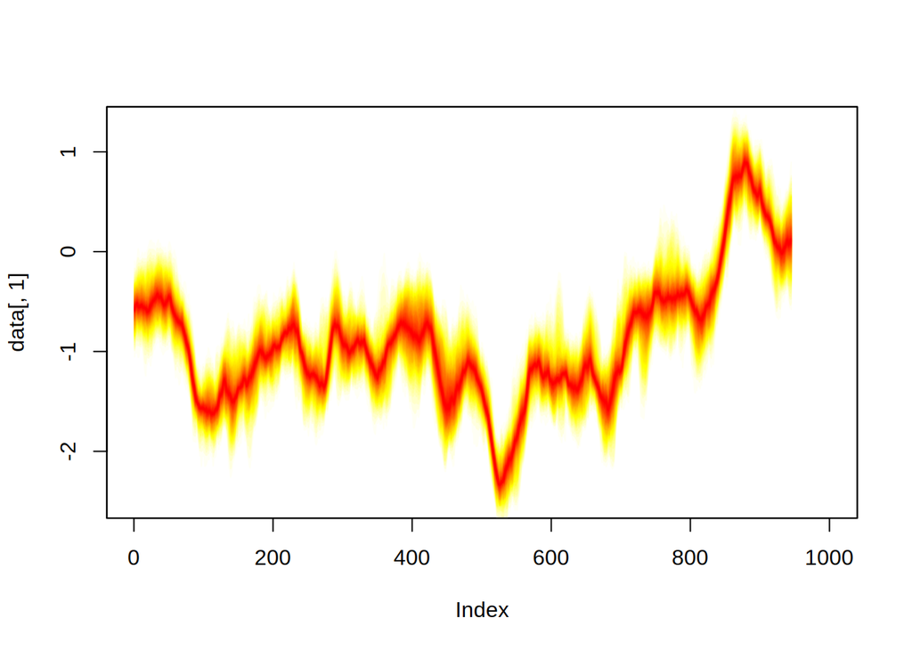

```r
library("fanplot")
fan0(data = th.mcmc)
```

*Original plot*

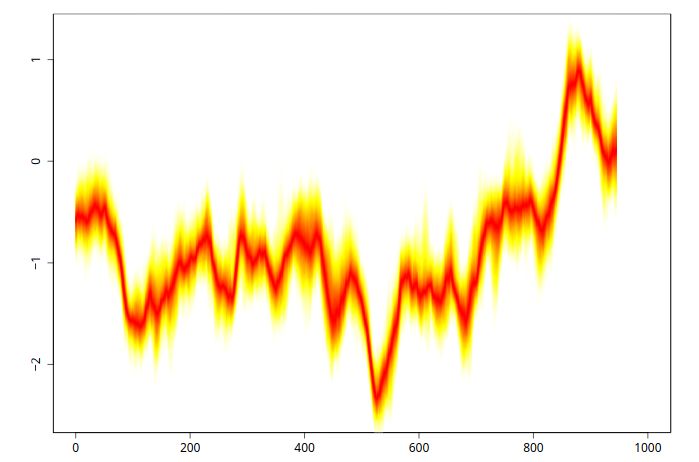

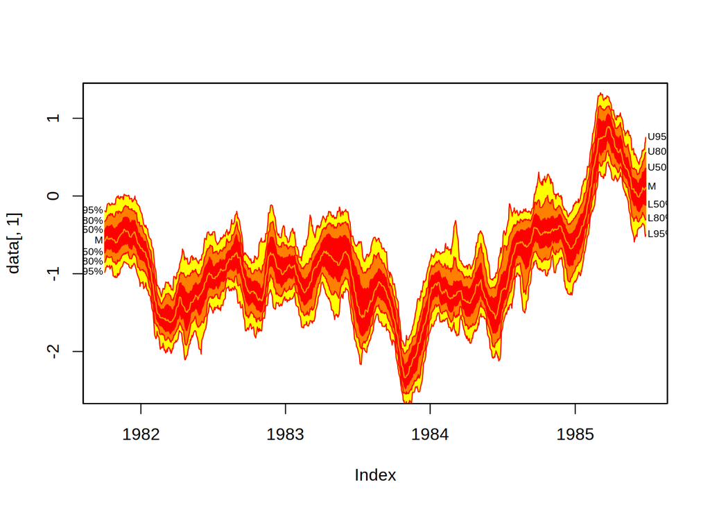

```r
library("zoo")
library("tsbugs")
# create irregular multiple time series
th.mcmc2 <- zoo(th.mcmc, order.by = svpdx$date)
# plot
fan0(data = th.mcmc2, type = "interval", ln = c(0.5, 0.8, 0.95),llab = TRUE, rcex = 0.6)
```

*Original plot*

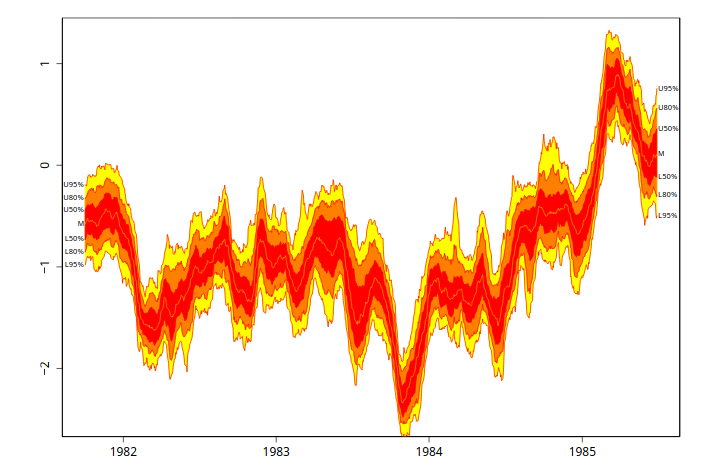

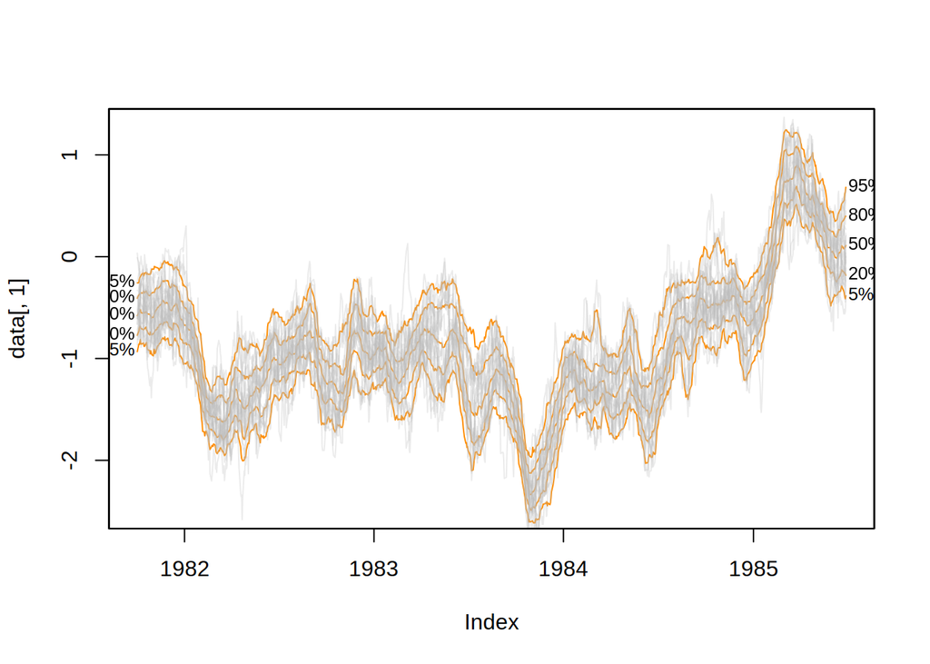

```r
# transparent fan with visible lines
fan0(th.mcmc2, ln = c(5, 20, 50, 80, 95), alpha = 0, ln.col = "darkorange", llab = TRUE)
# spaghetti lines
fan(th.mcmc2, style = "spaghetti", n.spag = 20, alpha = 0.3)
```

*Original plot*

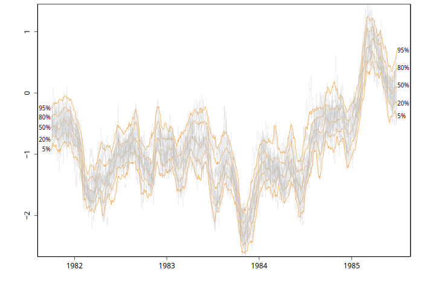

```r
head(boe)
```

|  | time0 | time | mode | uncertainty | skew |
| --- | --- | --- | --- | --- | --- |
| 1 | 2004 | 2004.00 | 1.34 | 0.2249 | 0 |
| 2 | 2004 | 2004.25 | 1.60 | 0.3149 | 0 |
| 3 | 2004 | 2004.50 | 1.60 | 0.3824 | 0 |
| 4 | 2004 | 2004.75 | 1.71 | 0.4274 | 0 |
| 5 | 2004 | 2005.00 | 1.77 | 0.4499 | 0 |
| 6 | 2004 | 2005.25 | 1.68 | 0.4761 | 0 |

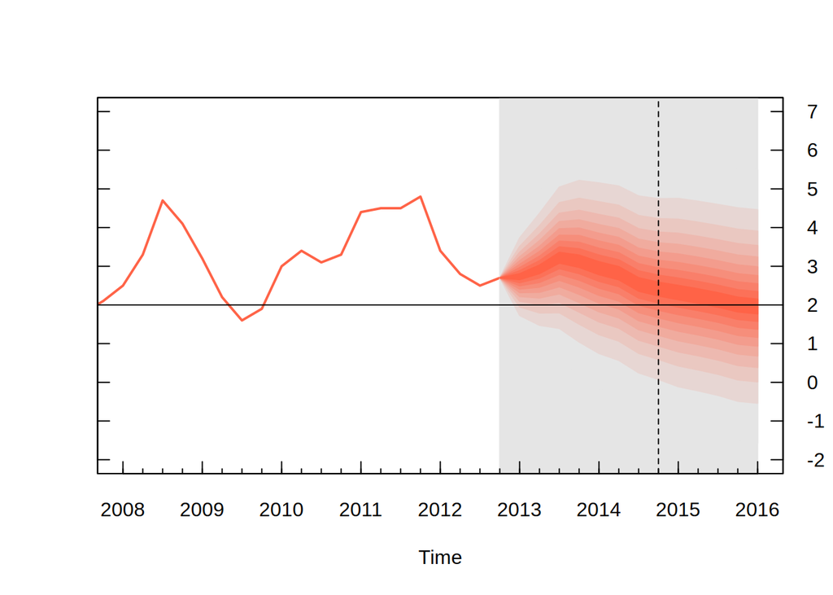

```r
# select relevant data
y0 <- 2013
boe0 <- subset(boe, time0 == y0)
k <- nrow(boe0)

# guess work to set percentiles the boe are plotting
p <- seq(0.05, 0.95, 0.05)
p <- c(0.01, p, 0.99)

# quantiles of split-normal distribution for each probability (row) at each future
# time point (column)
cpival <- matrix(NA, nrow = length(p), ncol = k)
for (i in 1:k)
  cpival[, i] <- qsplitnorm(p, mode = boe0$mode[i],
                            sd = boe0$uncertainty[i],
                            skew = boe0$skew[i])

# past data
plot(cpi, type = "l", col = "tomato", lwd = 2,xlim = c(y0 - 5, y0 + 3), ylim = c(-2, 7),xaxt = "n", yaxt = "n", ylab = "")
# background shading during forecast period
rect(y0 - 0.25, par("usr")[3] - 1, y0 + 3, par("usr")[4] + 1,border = "gray90", col = "gray90")
# add fan
fan(data = cpival, data.type = "values", probs = p,
    start = y0, frequency = 4, anchor = cpi[time(cpi) == y0 - 0.25],
    fan.col = colorRampPalette(c("tomato", "gray90")), ln = NULL, rlab = NULL)
# boe aesthetics
axis(2, at = -2:7, las = 2, tcl = 0.5, labels = FALSE)
axis(4, at = -2:7, las = 2, tcl = 0.5)
axis(1, at = 2008:2016, tcl = 0.5)
axis(1, at = seq(2008, 2016, 0.25), labels = FALSE, tcl = 0.2)
abline(h = 2)                   # boe cpi target
abline(v = y0 + 1.75, lty = 2)  # 2 year line
```

*Original plot*

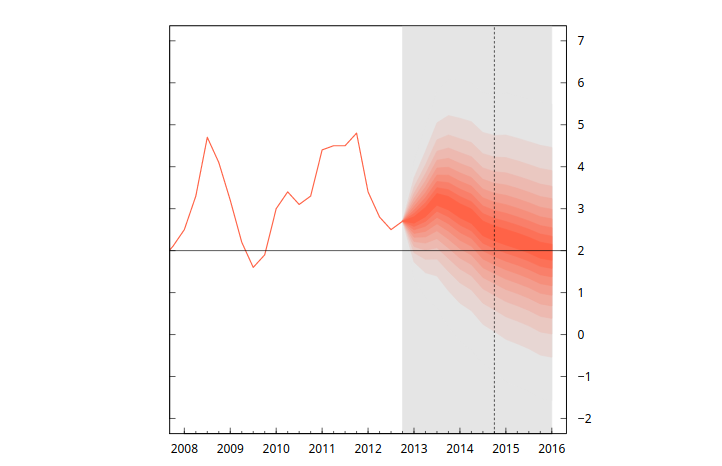

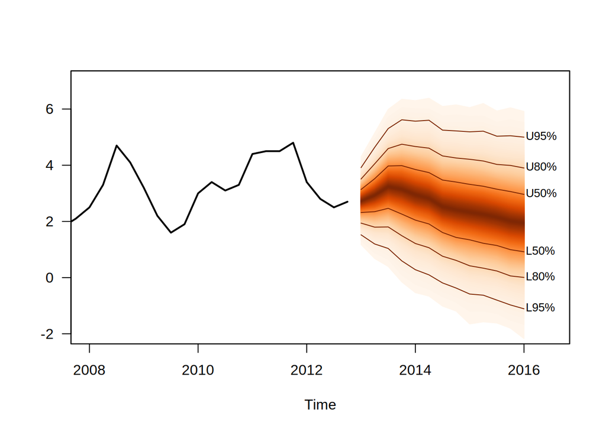

```r
# simulate future values
cpisim <- matrix(NA, nrow = 10000, ncol = k)
for (i in 1:k)
  cpisim[, i] <- rsplitnorm(n = 10000, mode = boe0$mode[i],
                            sd = boe0$uncertainty[i],
                            skew = boe0$skew[i])

# truncate cpi series and plot
cpi0 <- ts(cpi[time(cpi) < 2013], start = start(cpi), frequency = frequency(cpi))
plot(cpi0, type = "l", lwd = 2, las = 1, ylab = "",
     xlim = c(y0 - 5, y0 + 3.5), ylim = c(-2, 7))
# add fan
library("RColorBrewer")
fan(data = cpisim, type = "interval", probs = seq(0.01,0.99,0.01),
    start = y0, frequency = 4, ln = c(50,80,95), med.ln = FALSE,
    fan.col = colorRampPalette(colors = rev(brewer.pal(9, "Oranges"))))
```

*Original plot*

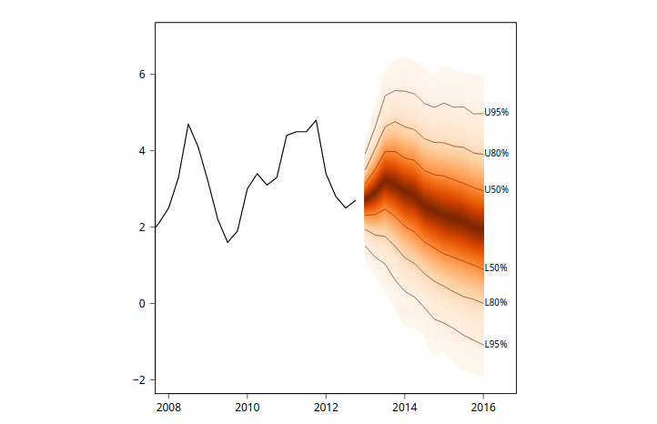

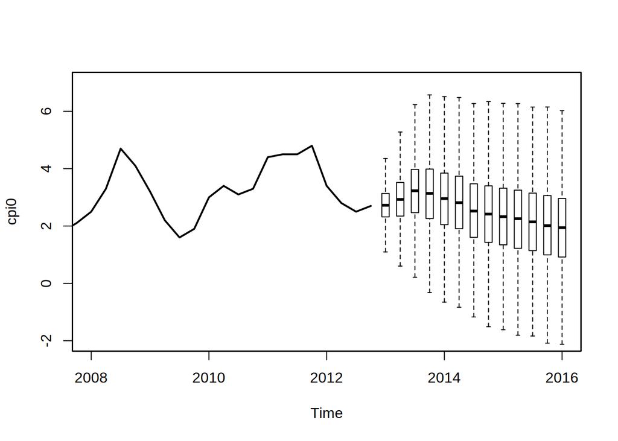

```r
# plot past data
plot(cpi0, type = "l", xlim = c(y0-5, y0+3), ylim = c(-2, 7), lwd = 2)

# box plots
fan(cpisim, style = "boxplot", start = y0, frequency = 4, outline = FALSE)
```

*Original plot*

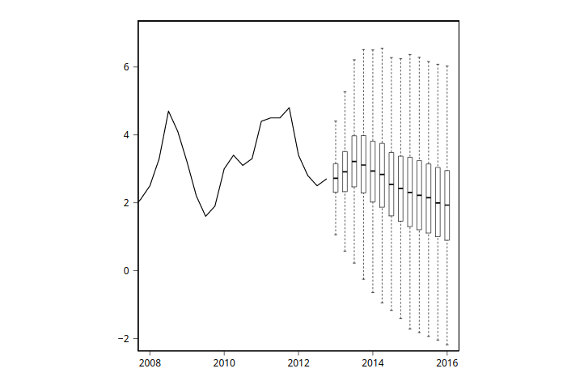

### Conclusion

Article was very easy to reproduce, one problem that came up was a package non availabile on CRAN. I dealt with it by using installing ‘.tar.gz’ file downloaded from internet.

## Article #2 - “Rmetrics - timeDate Package”

Article link: https://journal.r-project.org/archive/2011/RJ-2011-001/RJ-2011-001.pdf

### Reproduction

```r
library(timeDate)
showClass("timeDate")
```

```
## Class "timeDate" [package "timeDate"]
##
## Slots:
##
## Name:       Data    format FinCenter
## Class:   POSIXct character character
```

```r
Dates <- c("2009-09-28","2010-01-15")
Times <- c(  "23:12:55",  "10:34:02")
charvec <- paste(Dates, Times)
getRmetricsOption("myFinCenter")
```

```
## myFinCenter
##       "GMT"
```

```r
timeDate(charvec)
```

```
## GMT
## [1] [2009-09-28 23:12:55] [2010-01-15 10:34:02]
```

```r
setRmetricsOptions(myFinCenter = "Zurich")
timeDate(charvec)
```

```
## Zurich
## [1] [2009-09-28 23:12:55] [2010-01-15 10:34:02]
```

```r
timeDate(charvec, zone = "Tokyo")
```

```
## Zurich
## [1] [2009-09-28 16:12:55] [2010-01-15 02:34:02]
```

```r
timeDate(charvec, zone = "Zurich",
          FinCenter = "NewYork")
```

```
## NewYork
## [1] [2009-09-28 17:12:55] [2010-01-15 04:34:02]
```

```r
td <- timeDate(charvec, zone = "Zurich",
               FinCenter = "NewYork")
finCenter(td)
```

```
## [1] "NewYork"
```

```r
finCenter(td) <- "Zurich"
td
```

```
## Zurich
## [1] [2009-09-28 23:12:55] [2010-01-15 10:34:02]
```

```r
whichFormat(charvec)
```

```
## [1] "%Y-%m-%d %H:%M:%S"
```

```r
setRmetricsOptions(myFinCenter = "GMT")
#'timeDate'is now in the financial center "GMT"
timeDate(charvec)
```

```
## GMT
## [1] [2009-09-28 23:12:55] [2010-01-15 10:34:02]
```

```r
# first three days in January 2010,
timeSequence(from = "2010-01-01",
             to =   "2010-01-03", by = "day")
```

```
## GMT
## [1] [2010-01-01] [2010-01-02] [2010-01-03]
```

```r
# first 3 months in 2010:
timeSequence(from = "2010-01-01",
              to = "2010-03-31", by = "month")
```

```
## GMT
## [1] [2010-01-01] [2010-02-01] [2010-03-01]
```

```r
timeCalendar()
```

```
## GMT
##  [1] [2020-01-01] [2020-02-01] [2020-03-01] [2020-04-01] [2020-05-01]
##  [6] [2020-06-01] [2020-07-01] [2020-08-01] [2020-09-01] [2020-10-01]
## [11] [2020-11-01] [2020-12-01]
```

```r
timeCalendar(2010, m=1, d=1:4, h=16,
             zone = "Tokyo", FinCenter = "Zurich")
```

```
## Zurich
## [1] [2010-01-01 08:00:00] [2010-01-02 08:00:00] [2010-01-03 08:00:00]
## [4] [2010-01-04 08:00:00]
```

```r
timeDate(ch <- "2010-01-31 24:00:00")
```

```
## GMT
## [1] [2010-02-01]
```

```r
getRmetricsOption("myFinCenter")
```

```
## myFinCenter
##       "GMT"
```

```r
# change to Zurich:
  setRmetricsOptions(myFinCenter = "Zurich")

# first few financial centers:
head(listFinCenter())
```

```
## [1] "Africa/Abidjan"     "Africa/Accra"       "Africa/Addis_Ababa"
## [4] "Africa/Algiers"     "Africa/Asmara"      "Africa/Bamako"
```

```r
# European centers starting with A or B:
listFinCenter("Europe/[AB].*") # -> nine
```

```
## [1] "Europe/Amsterdam"  "Europe/Andorra"    "Europe/Athens"
## [4] "Europe/Belgrade"   "Europe/Berlin"     "Europe/Bratislava"
## [7] "Europe/Brussels"   "Europe/Bucharest"  "Europe/Budapest"
```

```r
Zurich()[64:67, ]
```

|  | Zurich | offSet | isdst | TimeZone | numeric |
| --- | --- | --- | --- | --- | --- |
| 64 | 2010-03-28 01:00:00 | 7200 | 1 | CEST | 1269738000 |
| 65 | 2010-10-31 01:00:00 | 3600 | 0 | CET | 1288486800 |
| 66 | 2011-03-27 01:00:00 | 7200 | 1 | CEST | 1301187600 |
| 67 | 2011-10-30 01:00:00 | 3600 | 0 | CET | 1319936400 |

```r
thisYear <- getRmetricsOption("currentYear")
Easter(thisYear:(thisYear+5))
```

```
## Zurich
## [1] [2020-04-12] [2021-04-04] [2022-04-17] [2023-04-09] [2024-03-31]
## [6] [2025-04-20]
```

```r
Easter(2010)
```

```
## Zurich
## [1] [2010-04-04]
```

```r
(tS <- timeSequence(Easter(2010, -2),
                    Easter(2010, +3)))
```

```
## Zurich
## [1] [2010-04-02] [2010-04-03] [2010-04-04] [2010-04-05] [2010-04-06]
## [6] [2010-04-07]
```

```r
(tS1 <- tS[isWeekday(tS)])
```

```
## Zurich
## [1] [2010-04-02] [2010-04-05] [2010-04-06] [2010-04-07]
```

```r
(tS2 <- tS[isBizday(tS, holidayZURICH(2010))])
```

```
## Zurich
## [1] [2010-04-06] [2010-04-07]
```

```r
dayOfWeek(tS2)
```

```
## 2010-04-06 2010-04-07
##      "Tue"      "Wed"
```

```r
charvec <- c("2011-03-01", "2011-04-01")
# Last day in quarter
timeLastDayInQuarter(charvec)
```

```
## Zurich
## [1] [2011-03-31] [2011-06-30]
```

```r
# Second Sunday of each month:
timeNthNdayInMonth(charvec, nday = 0, nth = 2)
```

```
## Zurich
## [1] [2011-03-13] [2011-04-10]
```

```r
# Closest Friday that occurred before:
timeNdayOnOrBefore(charvec, nday = 5)
```

```
## Zurich
## [1] [2011-02-25] [2011-04-01]
```

```r
showMethods("coerce", class = "timeDate")
```

```
## Function: coerce (package methods)
## from="ANY", to="timeDate"
## from="Date", to="timeDate"
## from="POSIXt", to="timeDate"
## from="timeDate", to="character"
## from="timeDate", to="data.frame"
## from="timeDate", to="Date"
## from="timeDate", to="list"
## from="timeDate", to="numeric"
## from="timeDate", to="POSIXct"
## from="timeDate", to="POSIXlt"
```

```r
ZH <- timeDate("2010-01-01 16:00", zone = "GMT",
               FinCenter = "Zurich")
NY <- timeDate("2010-01-01 18:00", zone = "GMT",
               FinCenter = "NewYork")
c(ZH, NY)
```

```
## Zurich
## [1] [2010-01-01 17:00:00] [2010-01-01 19:00:00]
```

```r
c(NY, ZH)
```

```
## NewYork
## [1] [2010-01-01 13:00:00] [2010-01-01 11:00:00]
```

### Conclusion

Article is fully reproductive, the only difference is seen due to the fact that functions takes current date.

## Article #3 - “rworldmap: A New R package forMapping Global Data”

Article link: https://journal.r-project.org/archive/2011/RJ-2011-006/RJ-2011-006.pdf

### Reproduction

```r
library(rworldmap)
data(countryExData)
sPDF <- joinCountryData2Map( countryExData,joinCode = "ISO3",nameJoinColumn = "ISO3V10")
```

```
## 149 codes from your data successfully matched countries in the map
## 0 codes from your data failed to match with a country code in the map
## 94 codes from the map weren't represented in your data
```

```r
data(countryExData)
sPDF <- joinCountryData2Map( countryExData,
                             joinCode = "ISO3",
                             nameJoinColumn = "ISO3V10")
```

```
## 149 codes from your data successfully matched countries in the map
## 0 codes from your data failed to match with a country code in the map
## 94 codes from the map weren't represented in your data
```

```r
mapDevice()
#create world map shaped window
mapCountryData(sPDF,nameColumnToPlot='BIODIVERSITY')
```

[output not shown]

```r
data(gridExData)
mapDevice()
#create world map shaped window
mapGriddedData(gridExData)
```

[output not shown]

Executing frame below ends up with error.

```r
# mapDevice()
#create world map shaped window
#mapBubbles(dF=getMap(),
           # nameZSize="POP2005",
           # nameZColour="REGION",
           # colourPalette="rainbow",
           # oceanCol="lightblue",
           # landCol="wheat")
```

```r
data(countryExData)
country2Region(countryExData,
               nameDataColumn="CLIMATE",
               joinCode="ISO3",
               nameJoinColumn="ISO3V10",
               regionType="Stern",
               FUN="mean")
```

|  | meanCLIMATEbyStern |
| --- | --- |
| Australasia | 56.92000 |
| Caribbean | 65.20000 |
| Central America | 76.11250 |
| Central Asia | 56.18000 |
| East Asia | 69.18462 |
| Europe | 73.87619 |
| North Africa | 71.00000 |
| North America | 62.70000 |
| South America | 77.01818 |
| South Asia | 77.22000 |

[output cut: 3 more lines]

```r
data(countryExData)
mapDevice()
#create world map shaped window
mapByRegion(countryExData,
            nameDataColumn="CLIMATE",
            joinCode="ISO3",
            nameJoinColumn="ISO3V10",
            regionType="Stern",
            FUN="mean")
```

[output not shown]

```
## 149 codes from your data successfully matched countries in the map
## 0 codes from your data failed to match with a country code in the map
## 94 codes from the map weren't represented in your data
```

```r
library(classInt)
library(RColorBrewer)
#getting smallexample data and joining to a map
data(countryExData)
sPDF <- joinCountryData2Map(countryExData,
                            joinCode = "ISO3",
                            nameJoinColumn = "ISO3V10",
                            mapResolution = "coarse")
```

```
## 149 codes from your data successfully matched countries in the map
## 0 codes from your data failed to match with a country code in the map
## 94 codes from the map weren't represented in your data
```

```r
#getting class intervals
classInt <- classIntervals( sPDF[["EPI"]],
                            n=5, style = "jenks")
catMethod = classInt[["brks"]]
#getting colours
colourPalette <- brewer.pal(5,'RdPu')
#plot map
mapDevice()
#create world map shaped window
mapParams <- mapCountryData(sPDF,
                            nameColumnToPlot="EPI",
                            addLegend=FALSE,
                            catMethod = catMethod,
                            colourPalette=colourPalette )
#adding legend
do.call(addMapLegend,
        c(mapParams,legendLabels="all",
          legendWidth=0.5,
          legendIntervals="data",
          legendMar = 2))
```

[output not shown]

### Conclusion

First part of article is easy to reproduce, only one frame is producing error. Unfortunately, after that author is using data freely available on the web, which isn’t availabile now. It’s probably due to the fact that article was written in 2011. To conclude I consider this article unreproducibal.

## Article #4 - “Raster Images in R Graphics”

Article link: https://journal.r-project.org/archive/2011/RJ-2011-008/RJ-2011-008.pdf

### Abstract

Article is about new support for R graphics engine, which improves graphics manipulation in R.

### Reproduction

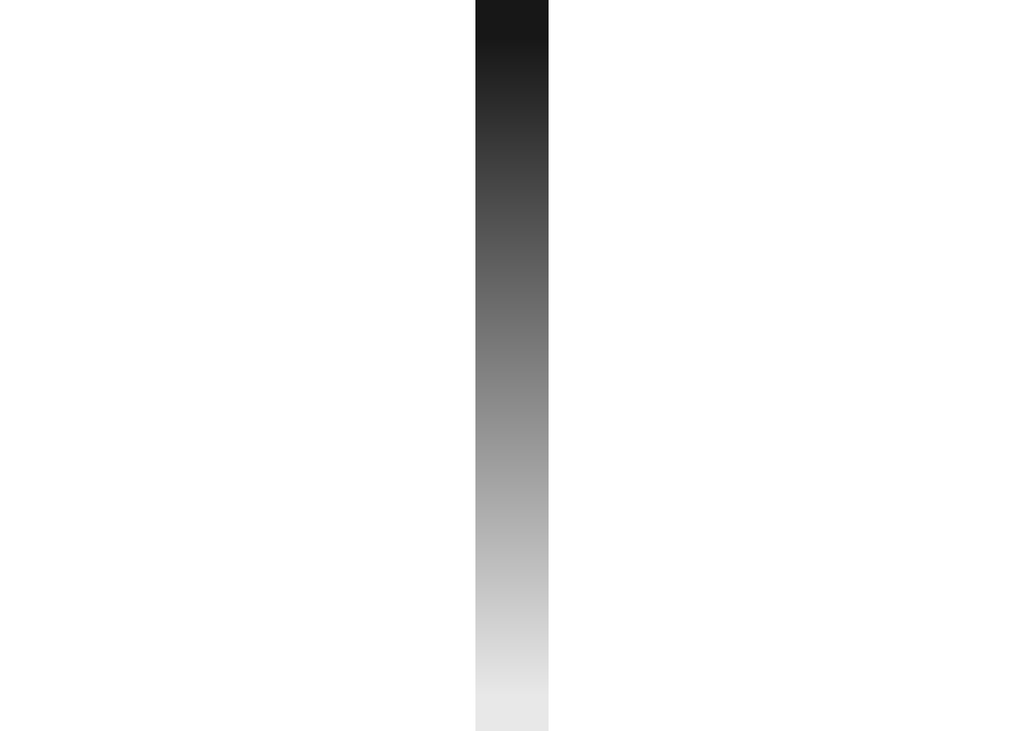

```r
library(grid)
grid.raster(1:10/11)
```

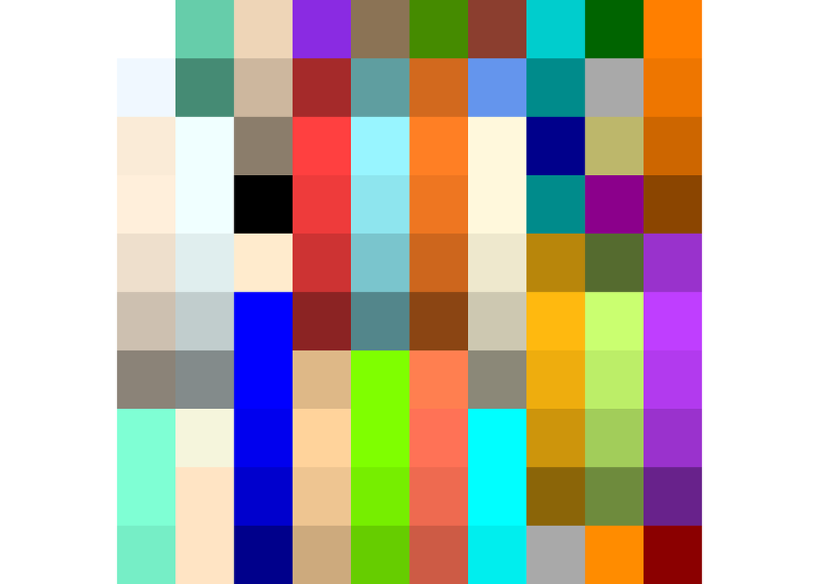

```r
grid.raster(matrix(colors()[1:100], ncol=10),
            interpolate=FALSE)
```

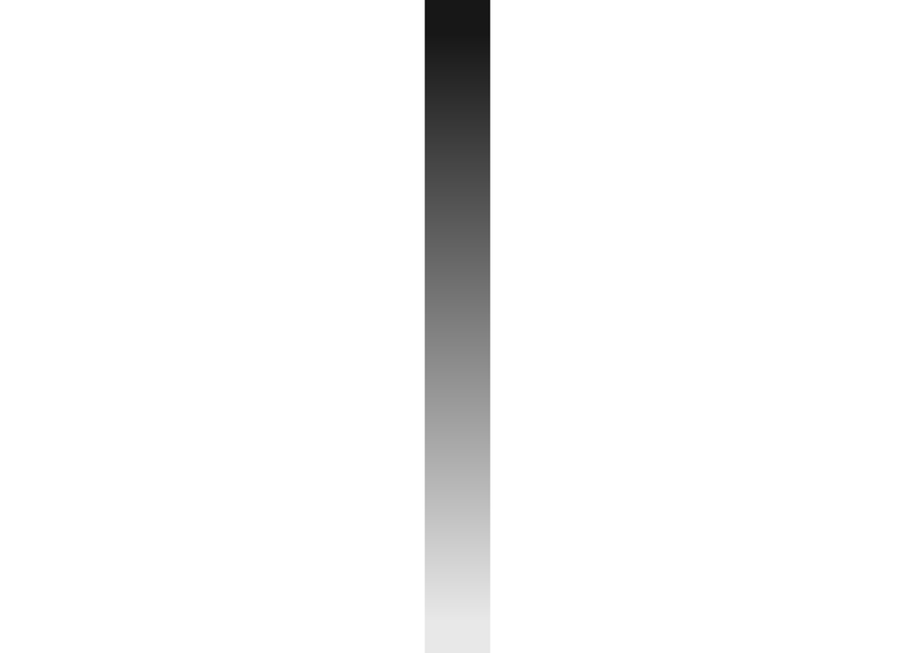

```r
grid.raster(as.raster(1:10, max=11))
```

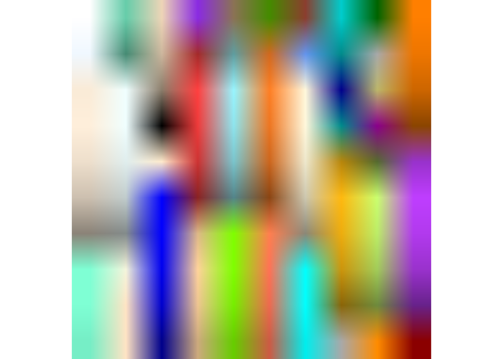

```r
grid.raster(1:10/11, interpolate=FALSE)
grid.raster(matrix(colors()[1:100], ncol=10))
```

[figure not shown]

```r
download.file("http://cran.r-project.org/Rlogo.jpg",
              "Rlogo.jpg")
library(ReadImages)
logo <- read.jpeg("Rlogo.jpg")
par(mar=rep(0, 4))
plot(logo)
```

[figure not shown]

```r
grid.raster(logo)
```

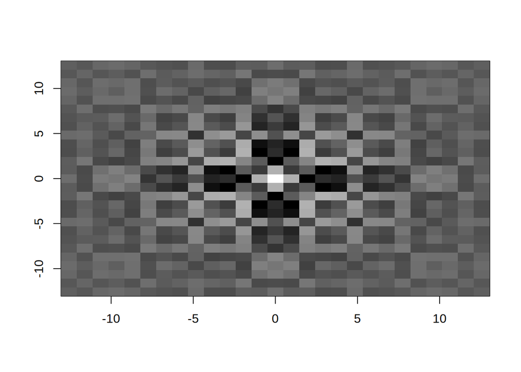

```r
x <- y <- seq(-4*pi, 4*pi, len=27)
r <- sqrt(outer(x^2, y^2, "+"))
z <- cos(r^2)*exp(-r/6)
image <- (z - min(z))/diff(range(z))
step <- diff(x)[1]
xrange <- range(x) + c(-step/2, step/2)
yrange <- range(y) + c(-step/2, step/2)
plot(x, y, ann=FALSE,
     xlim=xrange, ylim=yrange,
     xaxs="i", yaxs="i")
rasterImage(image,
            xrange[1], yrange[1],
            xrange[2], yrange[2],
            interpolate=FALSE)
```

[figure not shown]

```r
x <- c(0.00, 0.40, 0.86, 0.85, 0.69, 0.48,
       0.54, 1.09, 1.11, 1.73, 2.05, 2.02)
library(lattice)
barchart(1:12 ~ x, origin=0, col="white",
         panel=function(x, y, ...) {
           panel.barchart(x, y, ...)
           grid.raster(logo, x=0, width=x, y=y,
                       default.units="native",
                       just="left",
                       height=unit(2/37,
                                   "npc"))
           })
```

```r
z <- matrix(runif(500*500), ncol=500)

pdf("image.pdf")
image(z, col=grey(0:99/100))
dev.off()
```

```r
pdf("gridraster.pdf")
grid.raster(z, interp=FALSE)
dev.off()
```

```r
file.info("image.pdf", "gridraster.pdf")["size"]
```

|  | size |
| --- | --- |
| image.pdf | 1248484 |
| gridraster.pdf | 368179 |

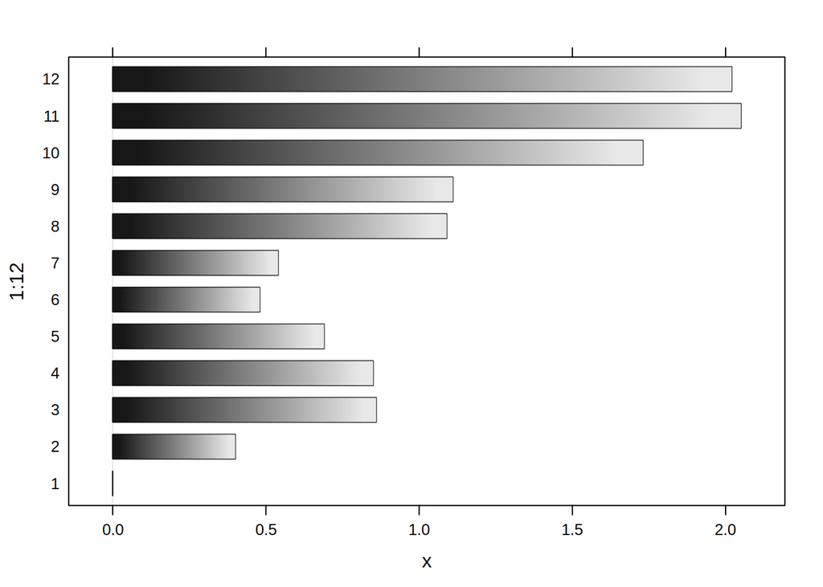

```r
barchart(1:12 ~ x, origin=0, col="white",
         panel=function(x, y, ...) {
           panel.barchart(x, y, ...)
           grid.raster(t(1:10/11), x=0,
                       width=x, y=y,
                       default.units="native",
                       just="left",
                       height=unit(2/37,
                                   "npc"))
           })
```

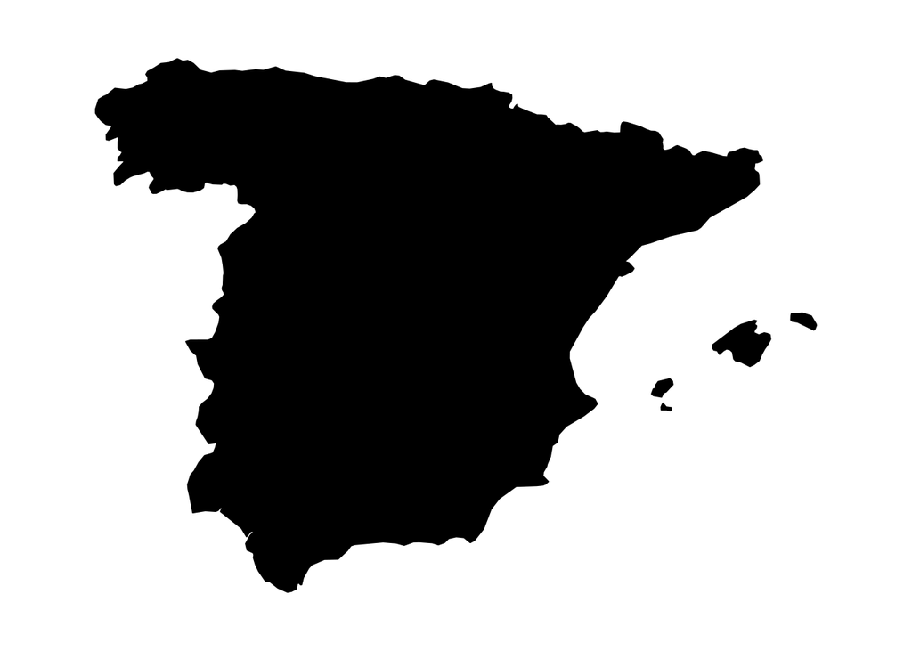

```r
library(maps)
par(mar=rep(0, 4))
map(region="Spain", col="black", fill=TRUE)

mask <- grid.cap()
```

```r
library(png)
espana <- readPNG("images/1000px-Flag_of_Spain.png")
espanaRaster <- as.raster(espana)

espanaRaster <- espanaRaster[, 1:667]
# ERROR
# mask <- mask[1:dim(mask)[1], ]

# espanaRaster[mask != "black"] <- "transparent"
# par(mar=rep(0, 4))
# map(region="Spain")
# grid.raster(espanaRaster, y=1, just="top")
# map(region="Spain", add=TRUE)
```

### Conclusion

As we can see, the article is preety much fully reproducible, except of the last example.